# What is python

Python is an **interpreted**, **object-oriented**, **high-level programming** language with **dynamic semantics**. Its high-level built in data structures, combined with **dynamic typing** and **dynamic binding**, make it very attractive for Rapid Application Development, as well as for use as a scripting or glue language to connect existing components together. Python's simple, easy to learn syntax emphasizes readability and therefore reduces the cost of program maintenance. Python supports modules and packages, which encourages *program modularity* and code reuse. The Python interpreter and the extensive standard library are available in source or binary form without charge for all major platforms, and can be freely distributed.  
(python.org)

**interpreted** An Interpreted Language is a Programming language in which the code is executed line by line by the interpreter. They differ from Compiled Languages in which the code is compiled into the machine language.

**object-oriented** Object-Oriented Programming (OOP) is a programming paradigm in computer science that relies on the concept of classes and objects. A *class* is an abstract blueprint that creates more specific, concrete *objects*. Classes often represent broad categories, like Car or Dog that share attributes. These classes define what attributes an instance of this type will have, like color, but not the value of those attributes for a specific object.

Classes can also contain functions called methods that are available only to objects of that type. These functions are defined within the class and perform some action helpful to that specific object type.

Class templates are used as a blueprint to create individual objects. These represent specific examples of the abstract class, like myCar or goldenRetriever. Each object can have unique values to the properties defined in the class.

**dynamic typing** means that a compiler or an interpreter assigns a type to all the variables at run-time. The type of a variable is decided based on its value.

**dynamic binding** languages perform type checking at runtime and the different objects respond differently to the same method call based on their individual implementations.

**dynamic allocation** memory resources are not declared previously, but dynamically adapted, i.e. no number is too big

# How to install python

There are different ways to install Python and related packages, but the best way is to start from Miniconda, or Miniforge (Mambaforge). They cames with a package and enviroment manager and it make the difference

#### No need to administration privilege

https://conda-forge.org/miniforge/#latest-release

download execute

to start python seach **prompt** on windows start

and type **python** on the shell

# first step on python

on the shell

```
>print('hello word')

>2+3

>sin(3.14)
NameError: name 'sin' is not defined. Did you mean: 'bin'?
```

pure python is quite limited, use of modules and packages are necessary for many applications

```
>import math
>math.sin(3.14)
```

# Python modules and Package

Python modules and Python packages are two mechanisms that facilitate modular programming.

Modular programming refers to the process of breaking a large, unwieldy programming task into separate, smaller, more manageable subtasks or modules. Individual modules can then be cobbled together like building blocks to create a larger application.

There are several advantages to modularizing code in a large application:

- **Simplicity**: Rather than focusing on the entire problem at hand, a module typically focuses on one relatively small portion of the problem. If you’re working on a single module, you’ll have a smaller problem domain to wrap your head around. This makes development easier and less error-prone.
- **Maintainability**: Modules are typically designed so that they enforce logical boundaries between different problem domains. If modules are written in a way that minimizes interdependency, there is decreased likelihood that modifications to a single module will have an impact on other parts of the program. (You may even be able to make changes to a module without having any knowledge of the application outside that module.) This makes it more viable for a team of many programmers to work collaboratively on a large application.
- **Reusability**: Functionality defined in a single module can be easily reused (through an appropriately defined interface) by other parts of the application. This eliminates the need to duplicate code.
- **Scoping**: Modules typically define a separate namespace, which helps avoid collisions between identifiers in different areas of a program. (One of the tenets in the Zen of Python is Namespaces are one honking great idea—let’s do more of those!)

https://realpython.com/python-modules-packages/

#### Some nomeclature

A `module` module is basically a bunch of related code saved in a file with the extension .py.\ Could containfunctions, classes, or variables in a module, but also runnable code.  
Python `packages` are basically a directory with hierarchical structured collection of modules and other package.  
On the use are quite the same

##### Module : import and namespace

Module contents are made available to the caller with the `import` statement. All methods and object defined in the module could be available on the sintax `name_module.object`

#### lets do a module

exit from python

> exit()  
> notepad Torino.py

```
club = 'Torino F.C.'

song = 'Forza Toro'

nemesis = 'Juventus'
championchip= [1927, 1942, 1945, 1946, 1947, 1948, 1975]

def team(player):
    print(f'player = {player}')

class FCteam(object):
    pass

if __name__ == "__main__":
    import webbrowser
    url = "https://www.youtube.com/watch?v=prdK3znXk4M"
    webbrowser.open(url, new=0, autoraise=True)
```

> save Torino.py

- club (a string)
- championchip (a list)
- team() (a function)
- FCteam (a class)

> start again python

```
import Torino

>print(Torino.song)

>Torino.team("Pulici")

>Torino.championchip
```

##### Library : import and namespace

Library contents are made available to the caller with the `import` statement. All methods and object defined in the module could be available on the sintax `name_library.object` To use internal module the name of the path should be assured

```
from tkinter import filedialog as fd    # from library tkinter import module filedialog renaming as fd

def open_file_selection():
    file = fd.askopenfilename()                       # use of the function askopenfilename of module  filedialog in tkinter
    print(file)

open_file_selection()
```

# How to install other moldules library and accessory

##### 3 methods (from safer to dangerous):

1. put the files/directory in a place that python know. (typically in the same directory), what happen, Happen.
2. use `conda` (or `mamba` aka conda on steroids). It is a package manager that check the dependencies of the module and possible conflict with the other installed modules, install what it is needed if a compromise is found. It could also create different environment in order to let coexist incompatible module.
3. use `pip`. It is a package manager that check the dependencies of the module and install what it is needed. It doesn't care if raise some incompatibility

### Location, Location, Location

1. - place the module/library in the same directory
   - use library site and and the site.addsitedir(sitedir)

### mamba/conda

2. - mamba install name_module
   - mamba install name_module -c biopython
   - mamba uninstall name_module
   - mamba update name_module

### pip

3. - pip install name_module
   - pip uninstall name_module
   - pip update name_module

#### Time to install something safe

```
# few tools for different kind of python
mamba install jupyterlab notebook ipython ipympl

# few tools for science
mamba install  numpy scipy matplotlib lmfit py3Dmol
```

#### mamba/conda cheatsheet

##### Getting Started

> conda info | *Verify Conda is installed, check version number*

> conda update -n base conda | *Update Conda to the current version*

> conda update anaconda | *Update all packages to the latest version of Anaconda*

##### Working with Environments

> conda create --name ENVNAME python=3.9 | *Create a new environment named ENVNAME with specific version of Python*

> conda activate ENVNAME | *Activate a named Conda environment*

> conda deactivate | *Deactivate current environment*

> conda list | *List all packages and versions in the active environment*

> conda list --name ENVNAME | *List all packages and versions in a named environment*

> conda list --revisions | *List all revisions made within the active environment*

> conda list --name ENVNAME --revisions | *List all revisions made in a specified environment*

> conda install --name ENVNAME --revision REV_NUMBER | *Restore an environment to a previous revision*

> conda remove --name ENVNAME --all | *Delete an entire environment*

##### Sharing Environments

> conda create --clone ENVNAME --name NEWENV | *Make an exact copy of an environment*

> conda env export --name ENVNAME > envname.yml | *Export an environment to a YAML file that can be read on Windows, macOS, and Linux*

> conda env create --file envname.yml | *Create an environment from YAML file*

> conda env create | *Create an environment from the file named environment.yml in the current directory*

> conda list --explicit > pkgs.txt | *Export an environment with exact package versions for one OS*

> conda create --name NEWENV --file pkgs.txt | *Create an environment based on exact package versions*

##### Using Packages and Channels

> anaconda search PKGNAME | *Find a package on all channels using the Anaconda Client*

> conda install conda-forge::PKGNAME | *Install package from a specific channel*

> conda install PKGNAME==3.1.4 | *Install a package by exact version number (3.1.4)*

> conda install "PKGNAME>2.5,<3.2" | *Install one of the listed versions (OR)*

> conda clean --all | *Remove unused cached files including unused packages*

> conda uninstall PKGNAME --name ENVNAME | *Remove a package from an environment*

# Three methods to run Python:

All start from the shell need to open a configured shell (linux mac users just open a shell)

*Windows users*

1. press button windows
2. type prompt -> open miniconda prompt

## 1) Interactive shell

as before but we type **i**python

now the enviroment allow introspection and autocomplete

```
import Torino

print(Torino.\tab)

>Torino.\tab

>Torino.\tab
```

## 2) executing a program

from the shell python Torino.py

[output not shown]

> import webbrowser

> url = "https://www.youtube.com/watch?v=prdK3znXk4M"

> webbrowser.open(url, new=0, autoraise=True)

the python is executing last part of the file

## 3) jupyter notebook

from the shell jupyter notebook

open a new browser window

[figure not shown]

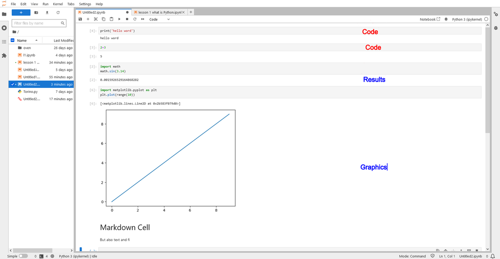

###### Command cell are here

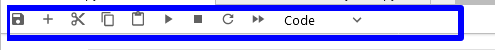

###### few shortcuts

If you are on a Mac, substitute `command` for `control`. Don't type the *+* (it means press both keys at once).

#### Shortcuts when in either *command mode* (outside the cells) or *edit mode* (inside a cell):

- `Shift` + `Enter` run selected cell or cells - if no cells below, insert a code cell below
- `Ctrl` + `B` toggle hide/show left sidebar
- `Ctrl` + `S` save and checkpoint
- `Ctrl` + `Shift` + `S` save as
- `Ctrl` + `F` find

#### Shortcuts when in *command mode* (outside the cells, no blinking cursor):

- `Enter` enter *edit mode* in the active cell
- Scroll up with the up arrow
- Scroll down with the down arrow
- `A` insert a new cell above the active cell
- `B` insert a new cell below the active cell
- `M` make the active cell a Markdown cell
- `Y` make the active cell a code cell
- `Shift` + `Up Arrow` select the current cell and the cell above
- `Shift` + `Down Arrow` select the current cell and the cell below
- `Ctrl` + `A` select all cells
- `X` cut the selected cell or cells
- `C` copy the selected cell or cells
- `V` paste the cell(s) which were copied or cut most recently
- `Shift + M` merge multiple selected cells into one cell
- `DD` (`D` twice) delete the active cell
- `00` (Zero twice) restart the kernel
- `Z` undo most recent command mode action

#### Shortcuts when in *edit mode* (inside a cell with a blinking cursor):

- `Esc` enter *command mode*
- `Tab` code completion (or indent if at start of line)
- `Shift` + `Tab` tooltip help
- `Ctrl` + `Shift` + `-` split the active cell at the cursor

The usual commands for code editors:

- `Ctrl` + `]` indent
- `Ctrl` + `[` dedent
- `Ctrl` + `/` toggle comment

Plus the usual shortcuts for select all, cut, copy, paste, undo, etc.

# Help

Well done modules and libraries are well documented. To access to the help of modules library function etc. just use the function `help`

```
import numpy
help(numpy)
```

in **ipython** just type '?' after the object of your curiosity

in **jupyter** just shift + tab after the object

# Good References

**Python Programming and Numerical Methods Kong et al**

Paper Book https://www.amazon.fr/Python-Programming-Numerical-Methods-Scientists/dp/0128195495  
Free website https://pythonnumericalmethods.berkeley.edu/notebooks/Index.html

**python like you mean it**  
http://www.pythonlikeyoumeanit.com/

# First TEST

try to install pyXRD from prestipino https://github.com/Prestipino/pyXRD  
but you can try to install the package that you needed